# Meteorological Covariate Data Access Tutorial

Kathryn Wheeler (kiwheel@bu.edu)

As part of the 2021 EFISA meeting tutorials, this document provides some examples of accessing and using covariate data (specifically air temperature).

See: https://projects.ecoforecast.org/neon4cast-docs/meteorology-inputs.html

# Load Required Libraries

```r
library('devtools')
```

```
## Error in get(genname, envir = envir) : object 'testthat_print' not found
```

```r
library('ncdf4')
library("reticulate")
# remotes::install_github("eco4cast/neon4cast")
# library('neon4cast')
```

# Example NEON Site Data

```r
siteID <- "HARV"
lat <- 42.5369
long <- -72.1727
```

# NOAA Global Ensemble Forecasting System (GEFS)

## Background

- 1 or 6 hour time resolution
- Each forecast has 31 ensemble members, which are each in a separate netcdf file
- For forecasts generated 4 times daily, the directories are organized by cycles 00, 06, 12, and 18
  - Forecasts extend 35 days in the future for midnight (00 UTC) forecast for ensemble members 01-30
    - Takes longer to download
  - Extend 16 days for midnight forecast ensemble member 00 and other cycles
- Following met variables are included:
  - Air temperature
  - Air pressure
  - Wind speed
  - Precipitation
  - Downwelling longwave radiation
  - Downwelling shortwave radiation
  - Relative humidity

## Ways to access via EFI

1. Click on file in browser (https://data.ecoforecast.org/minio/drivers/noaa/NOAAGEFS_1hr/)
2. Directly download individual files from the command line using the file address
3. Download files using aws.s3 commands
4. Use EFI’s R function code in neon4cast package called noaa.R, which downloads all ensemble members for a NEON site and forecast cycle

## Download From EFI server

```r
source_url('https://github.com/eco4cast/neon4cast/blob/main/R/noaa.R?raw=TRUE')

dte <- as.Date("2021-02-01")
time_interval <- "1hr"
cycle <- "00"
download_noaa(siteID=siteID,interval=time_interval,date=dte,cycle=cycle,dir='../data')
```

## Read Data File

```r
##Also see: https://github.com/eco4cast/neon4cast/blob/main/R/read_forecast.R
allTemperature <- matrix(nrow=30,ncol=841,NA) #Each row is one 35-day ensemble member for different time values on the columns
for(i in 1:30){
  if(i<10){
    i <- paste("0",as.character(i),sep="")
  }
  if(as.numeric(i)>0){
    fileName <- paste("../data/noaa/noaa/NOAAGEFS_",time_interval,"/",siteID,"/",dte,"/",cycle,
                      "/NOAAGEFS_",time_interval,"_",siteID,"_",dte,"T",cycle,"_",dte+35
                      ,"T",cycle,"_ens",i,".nc",sep="")
  }else{
    fileName <- paste("../data/noaa/noaa/NOAAGEFS_",time_interval,"/",siteID,"/",dte,"/",cycle,
                      "/NOAAGEFS_",time_interval,"_",siteID,"_",dte,"T",cycle,"_",dte+16
                      ,"T",cycle,"_ens",i,".nc",sep="")
  }
  nc <- nc_open(fileName)
  time <- as.integer(ncdf4::ncvar_get(nc, "time"))
  tustr <- lubridate::as_datetime(strsplit(ncdf4::ncatt_get(nc, varid = "time", "units")$value
                                           , " ")[[1]][3])
  time <- as.POSIXct.numeric((time*60*60), origin = tustr,tz = "UTC")
  temperature <- ncvar_get(nc,"air_temperature")-273 #Convert from Kelvin to Celcius
  allTemperature[as.numeric(i),] <- temperature
}
```

## Plot NOAA GEFS Forecasted Temperature

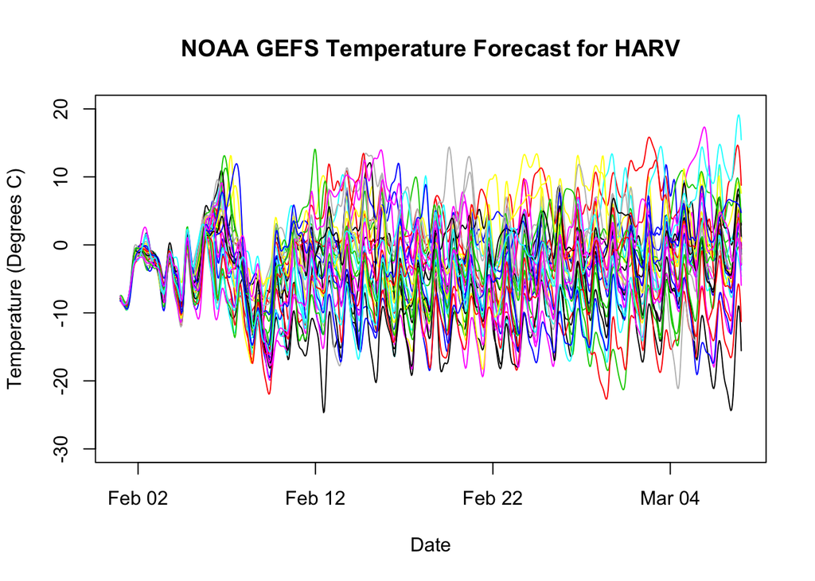

```r
  plot(time,allTemperature[1,],ylab="Temperature (Degrees C)",xlab="Date",main="NOAA GEFS Temperature Forecast for HARV",typ="l",col=1,ylim=c(-30,20))
  for(i in 2:nrow(allTemperature)){
    lines(time,allTemperature[i,],typ="l",col=as.numeric(i))
  }
```

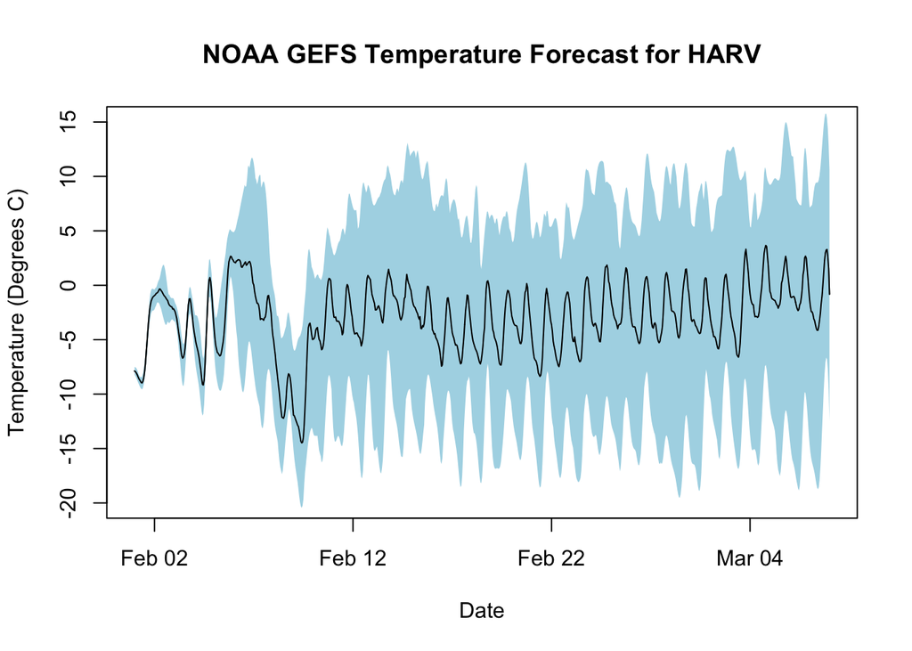

```r
  temp.ci <- apply(X=allTemperature,MARGIN = 2,FUN=quantile,c(0.025,0.5,0.975))
  #Plot by quantiles
  plot(time,temp.ci[2,],ylab="Temperature (Degrees C)",xlab="Date",main="NOAA GEFS Temperature Forecast for HARV",typ="l",ylim=c(-20,15))
    polygon(cbind(c(time, rev(time), time[1]), c(temp.ci[1,], rev(temp.ci[3,]), temp.ci[1,][1])),
    border = NA, col="lightblue")
    lines(time,temp.ci[2,])
```

# ERA5 Reanalysis Product

## Background

- 5th generation ECMWF reanalysis for global climate and weather
- Data available from 1950-1978 (preliminary back extension) and from 1979 onwards
- Hourly estimates for a large number of atmospheric, ocean-wave, and land-surface quantities
- 10-member ensemble at 3 hour intervals for uncertainty
- Available daily with a latency of ~ 5 days
- 0.25 degree x 0.25 degree spatial resolution (0.5 degree for uncertainty estimate)
- Example Variables
  - Evaporation
  - Lake bottom temperature
  - Lake depth
  - Lake ice depth
  - Total precipitation
  - LAI
  - 2m temperature
  - Air pressure
  - 2m dewpoint
  - Wind
  - Surface downwelling shortwave/longwave flux

## Download

```r
start_date <- as.Date("2021-01-01")
end_date <- as.Date("2021-01-31")

#Follow instructions on https://cds.climate.copernicus.eu/api-how-to to obtain a Climate Data Store Application Program Interface (cdsapi) key
fileName <- paste('../data/',siteID,"_",start_date,"_",end_date,"_era5AirTemperatureMembers.nc", sep ="")

if(!file.exists(fileName)){
  cdsapi <- reticulate::import("cdsapi")
  cclient <- cdsapi$Client()

  variables <- tibble::tribble(
    ~cf_name, ~units, ~api_name, ~ncdf_name,
    "air_temperature", "Kelvin", "2m_temperature", "t2m",
    "air_pressure", "Pa", "surface_pressure", NA_character_,
    NA_character_, "Kelvin", "2m_dewpoint_temperature", NA_character_,
    "precipitation_flux", "kg/m2/s", "total_precipitation", NA_character_,
    "eastward_wind", "m/s", "10m_u_component_of_wind", NA_character_,
    "northward_wind", "m/s", "10m_v_component_of_wind", NA_character_,
    "surface_downwelling_shortwave_flux_in_air", "W/m2", "surface_solar_radiation_downwards", NA_character_,
    "surface_downwelling_longwave_flux_in_air", "W/m2", "surface_thermal_radiation_downwards", NA_character_
  ) #Some examples (see more at: https://cds.climate.copernicus.eu/cdsapp#!/dataset/reanalysis-era5-single-levels?tab=overview)

  var <- variables[["api_name"]][[1]] #Only include the first variable

  area <- rep(round(c(lat, long) * 4) / 4, 2)

  do_next <- tryCatch({
    cclient$retrieve(
      "reanalysis-era5-single-levels",
      list(
        variable = var,
        product_type = 'ensemble_members',
        date = paste(start_date, end_date, sep = "/"),
        time = "00/to/23/by/1",
        area = area,
        grid = c(0.25, 0.25),
        format = "netcdf"
      ),
      fileName
    )
    FALSE
  }, error = function(e) {
    print("Failed to download")
    TRUE
  })
}
```

## Read Data File

```r
nc <- nc_open(fileName) #10 ensemble members in file
temperature <- ncvar_get(nc)-273
time <- as.integer(ncdf4::ncvar_get(nc, "time"))
time <- as.POSIXct(time*3600, origin = "1900-01-01",tz = "GMT")
```

## Plot

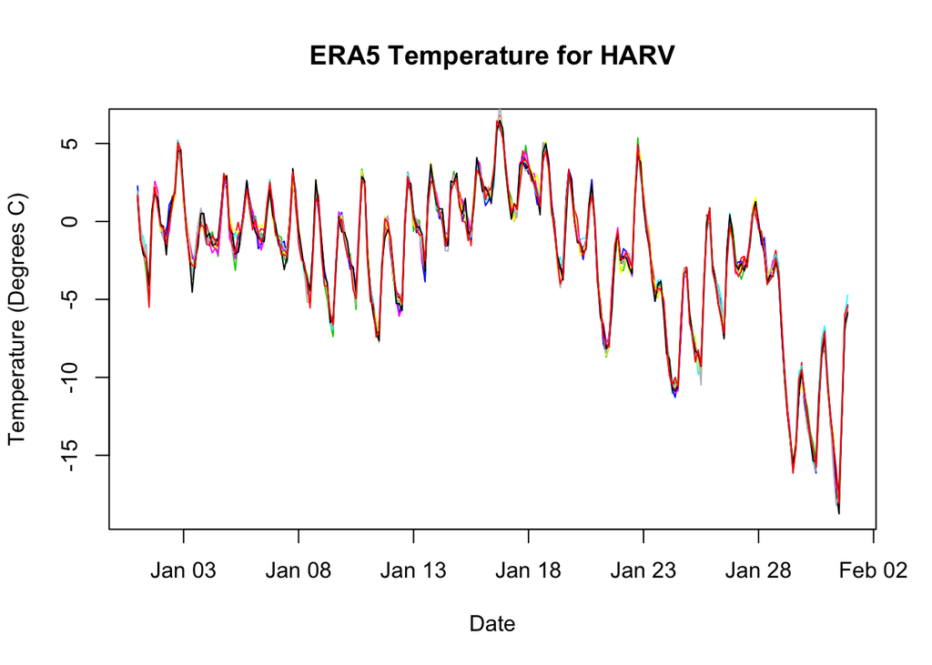

```r
plot(time,temperature[1,],typ="l",ylab="Temperature (Degrees C)",xlab="Date",main="ERA5 Temperature for HARV")

  for(i in 2:nrow(temperature)){
    lines(time,temperature[i,],typ="l",col=as.numeric(i))
  }
```

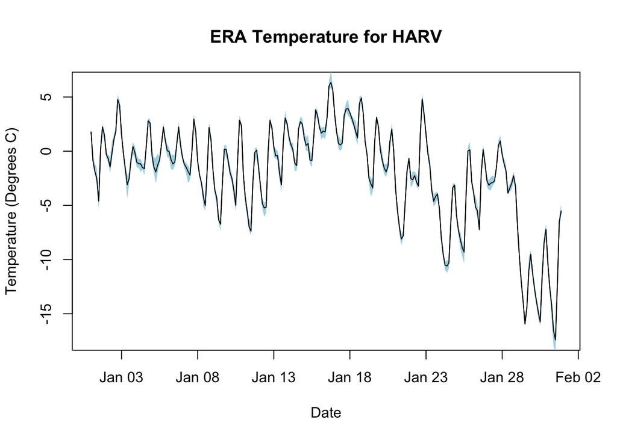

```r
  temp.ci <- apply(X=temperature,MARGIN = 2,FUN=quantile,c(0.025,0.5,0.975))
  #Plot by quantiles
  plot(time,temp.ci[2,],ylab="Temperature (Degrees C)",xlab="Date",main="ERA Temperature for HARV",typ="l")
    polygon(cbind(c(time, rev(time), time[1]), c(temp.ci[1,], rev(temp.ci[3,]), temp.ci[1,][1])),
    border = NA, col="lightblue")
    lines(time,temp.ci[2,])
```